# analysis

16 05 2021

## Data Preprocessing

```r
library(readr)
library(dplyr)
amazon <- read_csv("../data/amazon.csv")
amazon %>%
   select(title,viewed_bought,rating,rating_count,isbn) %>%
   filter(title != "") %>%
   filter(viewed_bought != "") %>%
   filter(!grepl("img alt",viewed_bought)) -> df
df
```

```
## # A tibble: 339 x 5
##    title                viewed_bought              rating    rating_count isbn
##    <chr>                <chr>                      <chr>     <chr>        <chr>
##  1 The Little Book of … The Bogleheads' Guide to … 4.7 out … 4,339 ratin… 978-1…
##  2 Predictably Irratio… Thinking, Fast and Slow    4.6 out … 3,996 ratin… null
##  3 Misbehaving: The Ma… The Winner's Curse: Parad… 4.6 out … 1,598 ratin… 978-0…
##  4 Nudge: Improving De… Thinking, Fast and Slow    4.3 out … 1,562 ratin… 978-0…
##  5 The Power of Habit:… Customer Review:  Helped … 4.6 out … 16,221 rati… 978-0…
##  6 The Intelligent Inv… One Up On Wall Street: Ho… 4.7 out … 23,818 rati… null
##  7 The Power of Habit:… The 80/20 Principle: The … 4.6 out … 16,221 rati… 978-0…
##  8 Your Money or Your … Financial Freedom: A Prov… 4.5 out … 2,535 ratin… 978-0…
##  9 Misbehaving: The Ma… Irrational Exuberance: Re… 4.6 out … 1,598 ratin… 978-0…
## 10 Your Money or Your … Brand New Book but the co… 4.5 out … 2,535 ratin… 978-0…
## # … with 329 more rows
```

## Generating Degree and Vertex Labels

```r
library(igraph)
g<-graph_from_data_frame(df)
DEG = tryCatch(degree(g))
VERTEXLAB = ifelse(DEG > 10, V(g)$name, NA)
```

## Initial Plotting

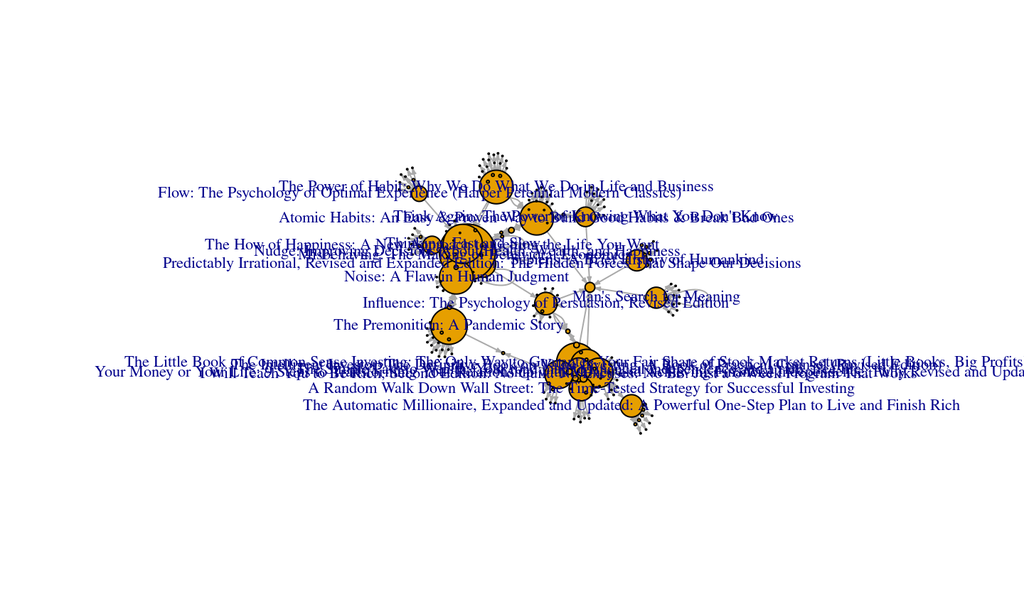

```r
plot(g,
      vertex.size = degree(g),
      vertex.label.cex = .7,
      vertex.label = VERTEXLAB,
      edge.arrow.size=.2,
      layout = layout.fruchterman.reingold(g))
```

## Plot with Rescaling and Exporting

```r
lo <- layout_with_kk(g) ## create a layout

lo <- norm_coords(lo, ymin=-1, ymax=1, xmin=-1, xmax=1)
## I think this tells igraph to normalize the coordinates of the
## layout relative to the space you're working with


resfactor = 3
png(filename="amazon.png", res = 72*resfactor, height=2500*resfactor, width=1900*resfactor)

plot(g, edge.arrow.width = .25,
     edge.arrow.size = .25,
     vertex.label.dist = 1,
     vertex.label.cex = .74,
     vertex.size = 5,
     rescale=FALSE,
     layout=lo*2)
dev.off()
```

## Plotting with Simpify

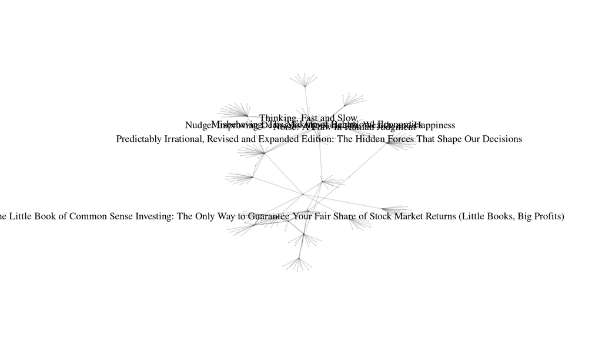

```r
plot(simplify(g),
     vertex.size= 0.01,
     edge.arrow.size=0.001,
     vertex.label.cex = 0.75,
     vertex.label.color = "black"  ,
     vertex.frame.color = adjustcolor("white", alpha.f = 0),
     vertex.color = adjustcolor("white", alpha.f = 0),
     edge.color=adjustcolor(1, alpha.f = 0.15),
     display.isolates=FALSE,vertex.label=ifelse(page_rank(g)$vector > 0.007 , V(g)$name, NA),
     layout = layout.auto(simplify(g)))
```

## Plotting with Most Important Labels

```r
## this ensures the starting random position is the same
## for the layouts that use a random starting position
set.seed(225)

ig <- g
l <- layout.fruchterman.reingold(ig, niter=3000, area=vcount(ig)^5*10)
```

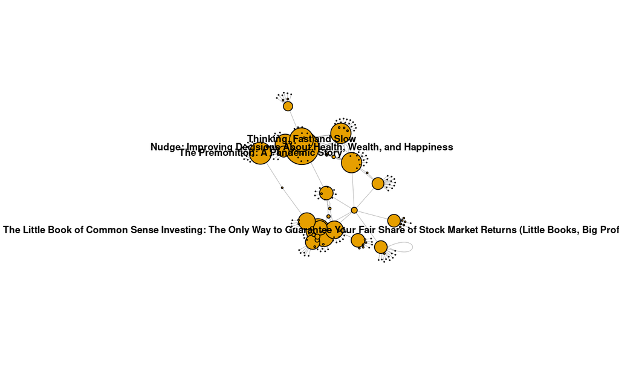

```r
DEG = tryCatch(degree(ig))

VERTEXLAB = ifelse(DEG > 25, V(g)$name, NA)

plot(ig, layout=l,
     edge.arrow.size=0.005,
     vertex.label.family="Helvetica",
     vertex.label.font=2,
     vertex.shape="circle",
     vertex.size=DEG,
     vertex.label.color="black",
     vertex.size = degree(ig),
     vertex.label.cex = .7,
     vertex.label = VERTEXLAB,
     edge.arrow.size=.02,
     edge.width=0.5)
```

## Plot with VisNetwork

- Advantages: Zoomable, Clickable, Neigboor Highlight, Possibility of change node positions, embedding to web apps, selecting ID by combo box
- Disadvantages: Reporting overall network
- Solution: Printing different parts

```r
library(visNetwork)
library(dplyr)
V(g)$size <- degree(g)
V(g)$color <- c("green", "grey","blue","red","orange","yellow")
#V(g)$color <- c("green")
visNetwork::visIgraph(g, physics= FALSE)%>%
  visInteraction(navigationButtons = TRUE) %>%
   visOptions(selectedBy = "group",
                highlightNearest = TRUE,
                nodesIdSelection = TRUE) %>%
                  visPhysics(stabilization = FALSE)
```

[interactive chart not shown]

## Listing by degree centrality

What it means? (1) There are some books that has living in the intersection of the book that viewing by the user and searched by the same users. These books has high likelihood of popularity from some reasons.  
(2) The first book is the initial books that algorithm has started to search.

```r
data.frame(degree(g)) %>% arrange(desc(`degree.g.`))
```

```
##                                                                                                                                                                                                 degree.g.
## Nudge: Improving Decisions About Health, Wealth, and Happiness                                                                                                                                         40
## The Little Book of Common Sense Investing: The Only Way to Guarantee Your Fair Share of Stock Market Returns (Little Books, Big Profits)                                                               28
## Thinking, Fast and Slow                                                                                                                                                                                28
## The Premonition: A Pandemic Story                                                                                                                                                                      26
## The Power of Habit: Why We Do What We Do in Life and Business                                                                                                                                          24
## Noise: A Flaw in Human Judgment                                                                                                                                                                        24
## Atomic Habits: An Easy & Proven Way to Build Good Habits & Break Bad Ones                                                                                                                              24
## The Intelligent Investor: The Definitive Book on Value Investing. A Book of Practical Counsel (Revised Edition)                                                                                        23
## Your Money or Your Life: 9 Steps to Transforming Your Relationship with Money and Achieving Financial Independence: Fully Revised and Updated for 2018                                                 21
## Misbehaving: The Making of Behavioral Economics                                                                                                                                                        20
## I Will Teach You to Be Rich, Second Edition: No Guilt. No Excuses. No BS. Just a 6-Week Program That Works                                                                                             20
## Predictably Irrational, Revised and Expanded Edition: The Hidden Forces That Shape Our Decisions                                                                                                       19
## A Random Walk Down Wall Street: The Time-Tested Strategy for Successful Investing                                                                                                                      17
## The Simple Path to Wealth: Your road map to financial independence and a rich, free life                                                                                                               17
## Influence: The Psychology of Persuasion, Revised Edition                                                                                                                                               16
## The Automatic Millionaire, Expanded and Updated: A Powerful One-Step Plan to Live and Finish Rich                                                                                                      16
## Man's Search for Meaning                                                                                                                                                                               15
## Sapiens: A Brief History of Humankind                                                                                                                                                                  15
## Think Again: The Power of Knowing What You Don't Know                                                                                                                                                  14
## The How of Happiness: A New Approach to Getting the Life You Want                                                                                                                                      13
## Flow: The Psychology of Optimal Experience (Harper Perennial Modern Classics)                                                                                                                          11
## Urban Survivor                                                                                                                                                                                          7
## A Beginner's Guide to the Stock Market: Everything You Need to Start Making Money Today                                                                                                                 6
## One Up On Wall Street: How To Use What You Already Know To Make Money In The Market                                                                                                                     5
## The Bogleheads' Guide to Investing                                                                                                                                                                      4
```

[output cut: 174 more lines]

## Cliques

What it means(?) Remember the definition. A clique is fully connected full network. (2) As you see in the all cliques are related topics because a person for instance has interest to finance looks finance book (Clique 1), (3) Look clique 5: It is totally about the topics out of finance.

```r
max_cliques(g,min=4)
```

```
## [[1]]
## + 4/199 vertices, named, from 9e390d9:
## [1] The Bogleheads' Guide to Investing
## [2] The Little Book of Common Sense Investing: The Only Way to Guarantee Your Fair Share of Stock Market Returns (Little Books, Big Profits)
## [3] The Simple Path to Wealth: Your road map to financial independence and a rich, free life
## [4] A Random Walk Down Wall Street: The Time-Tested Strategy for Successful Investing
##
## [[2]]
## + 4/199 vertices, named, from 9e390d9:
## [1] One Up On Wall Street: How To Use What You Already Know To Make Money In The Market
## [2] The Little Book of Common Sense Investing: The Only Way to Guarantee Your Fair Share of Stock Market Returns (Little Books, Big Profits)
## [3] A Random Walk Down Wall Street: The Time-Tested Strategy for Successful Investing
## [4] The Intelligent Investor: The Definitive Book on Value Investing. A Book of Practical Counsel (Revised Edition)
##
## [[3]]
## + 4/199 vertices, named, from 9e390d9:
## [1] A Beginner's Guide to the Stock Market: Everything You Need to Start Making Money Today
## [2] The Little Book of Common Sense Investing: The Only Way to Guarantee Your Fair Share of Stock Market Returns (Little Books, Big Profits)
## [3] A Random Walk Down Wall Street: The Time-Tested Strategy for Successful Investing
## [4] The Intelligent Investor: The Definitive Book on Value Investing. A Book of Practical Counsel (Revised Edition)
##
## [[4]]
## + 4/199 vertices, named, from 9e390d9:
## [1] The Intelligent Investor: The Definitive Book on Value Investing. A Book of Practical Counsel (Revised Edition)
## [2] The Little Book of Common Sense Investing: The Only Way to Guarantee Your Fair Share of Stock Market Returns (Little Books, Big Profits)
## [3] The Simple Path to Wealth: Your road map to financial independence and a rich, free life
## [4] A Random Walk Down Wall Street: The Time-Tested Strategy for Successful Investing
##
## [[5]]
## + 4/199 vertices, named, from 9e390d9:
## [1] Predictably Irrational, Revised and Expanded Edition: The Hidden Forces That Shape Our Decisions
## [2] Misbehaving: The Making of Behavioral Economics
## [3] Thinking, Fast and Slow
## [4] Nudge: Improving Decisions About Health, Wealth, and Happiness
```

## Louvain’s Algorithm for Community Detection:

> Louvain’s algorithm was proposed by Vincent D. Blondel, Jean-Loup Guillaume, Renaud Lambiotte and Etienne Lefebvre in this paper in 2008. It was named after the city in Belgium where one of the proposers Etienne Lefebvre first developed this algorithm during his Master thesis at UCL( Louvain-la-Neuve ) in March,2007.

## Introduction and Cost Function

> Any unsupervised or supervised machine learning algorithm needs a loss/optimisation/cost function to decide on the convergence criterion. In the community detection scenario, Modularity is one most suitable optimisation metric. Louvain’s algorithm is based on optimising the Modularity very effectively. Before discussing the steps followed in the algorithm, let us understand Modularity concept first.

## Introduction and Cost Function

> The quality of the communities referred as partitions hereafter is measured by Modularity of the partition. Modularity Q is defined as the formula shown in the below figure. [Source](https://medium.com/walmartglobaltech/demystifying-louvains-algorithm-and-its-implementation-in-gpu-9a07cdd3b010)

## Introduction and Cost Function

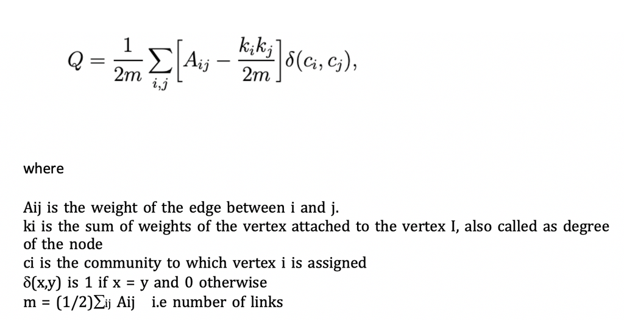

Louvain

## Louvain Basic Example

Finding best segmentation that all clusters are best modularity

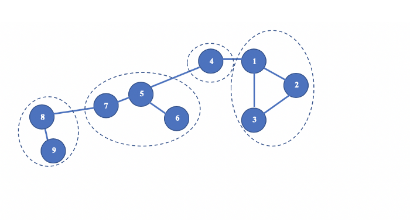

Louvain2

## Finding Structures with Louvain

```r
gx <- graph_from_data_frame(df,directed=F)
cluster_louvain(gx)[1:2]
```

```
## $`1`
##  [1] "Predictably Irrational, Revised and Expanded Edition: The Hidden Forces That Shape Our Decisions"
##  [2] "Misbehaving: The Making of Behavioral Economics"
##  [3] "Nudge: Improving Decisions About Health, Wealth, and Happiness"
##  [4] "Thinking, Fast and Slow"
##  [5] "The Winner's Curse: Paradoxes and Anomalies of Economic Life"
##  [6] "Irrational Exuberance: Revised and Expanded Third Edition"
##  [7] "The Honest Truth About Dishonesty: How We Lie to Everyone--Especially Ourselves"
##  [8] "The Wizard of Ads: Turning Words into Magic and Dreamers into Millionaires"
##  [9] "Behavioral Economics: The Basics"
## [10] "Blink: The Power of Thinking Without Thinking"
## [11] "Justice: What's The Right Thing To Do?"
## [12] "Health Policy Issues: An Economic Perspective, Seventh Edition"
## [13] "Superforecasting: The Art and Science of Prediction"
## [14] "The Art of Thinking Clearly"
```

[output cut: 30 more lines]

## Visualization with Louvain Clusters

```r
## greedy method (hiearchical, fast method)
c3 = cluster_louvain(gx)
coords = layout_with_fr(gx)

## modularity measure
modularity(c3)
```

```
## [1] 0.7546532
```

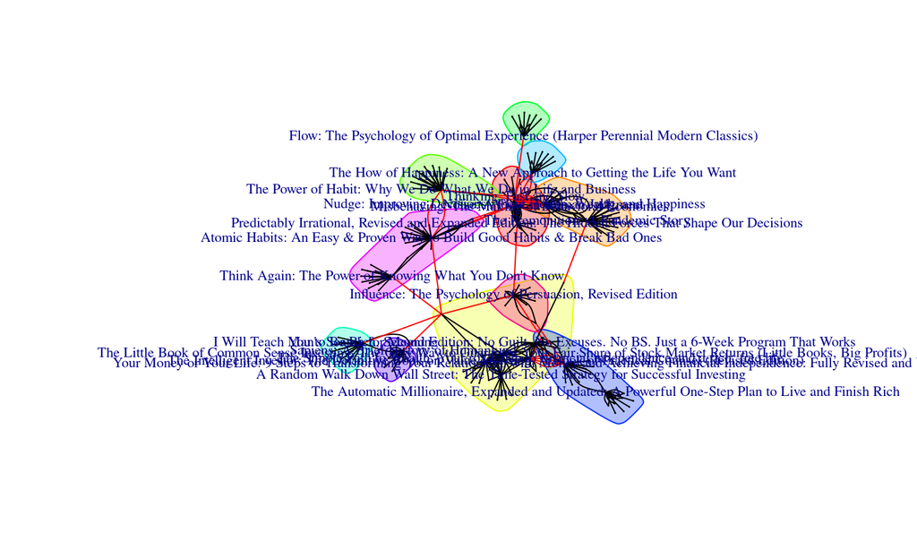

```r
### [1] 0.4012985
## plot communities with shaded regions
DEG = tryCatch(degree(gx))

VERTEXLAB = ifelse(DEG > 10, V(gx)$name, NA)

plot(c3, gx, layout=coords,
      vertex.size = .3,
      vertex.label.cex = .7,
      vertex.label = VERTEXLAB)
```

## Visualization with Edge Betweenness Clusters

As you see it calculates different communities

The idea of the edge betweenness based community structure detection is that it is likely that edges connecting separate modules have high edge betweenness as all the shortest paths from one module to another

```r
## greedy method (hiearchical, fast method)
c3 = cluster_edge_betweenness(gx)
coords = layout_with_fr(gx)

## modularity measure
modularity(c3)
```

```
## [1] 0.7598089
```

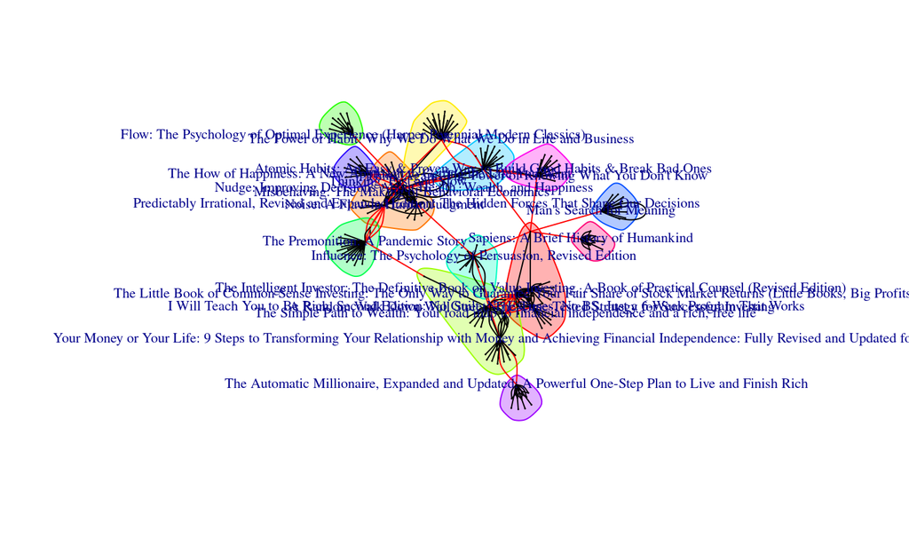

```r
### [1] 0.4012985
## plot communities with shaded regions
DEG = tryCatch(degree(gx))

VERTEXLAB = ifelse(DEG > 10, V(gx)$name, NA)

plot(c3, gx, layout=coords,
      vertex.size = .3,
      vertex.label.cex = .7,
      vertex.label = VERTEXLAB)
```

## List Based by Edge Betweenness Cluster

```r
c3 = cluster_edge_betweenness(gx)
c3[1:2]
```

```
## $`1`
##  [1] "The Little Book of Common Sense Investing: The Only Way to Guarantee Your Fair Share of Stock Market Returns (Little Books, Big Profits)"
##  [2] "The Intelligent Investor: The Definitive Book on Value Investing. A Book of Practical Counsel (Revised Edition)"
##  [3] "A Random Walk Down Wall Street: The Time-Tested Strategy for Successful Investing"
##  [4] "The Bogleheads' Guide to Investing"
##  [5] "One Up On Wall Street: How To Use What You Already Know To Make Money In The Market"
##  [6] "Urban Survivor"
##  [7] "The Most Famous Investment Book in the World"
##  [8] "A Beginner's Guide to the Stock Market: Everything You Need to Start Making Money Today"
##  [9] "The Math Sorcerer's Lair"
## [10] "The Intelligent Investor Short Reads"
## [11] "Buffett’s 2-Step Stock Market Strategy: Know When to Buy A Stock, Become a Millionaire, Get The Highest Returns"
## [12] "The Intelligent Investor: The Definitive Book on Value Investing. A…"
## [13] "The Intelligent Investor Short Reads Urban Survivor"
## [14] "How to Day Trade for a Living: A Beginner’s Guide to Trading Tools and Tactics, Money Management, Discipline and Trading Psychology (Stock Market Trading and Investing)"
```

[output cut: 34 more lines]

## Comparison

Almost same

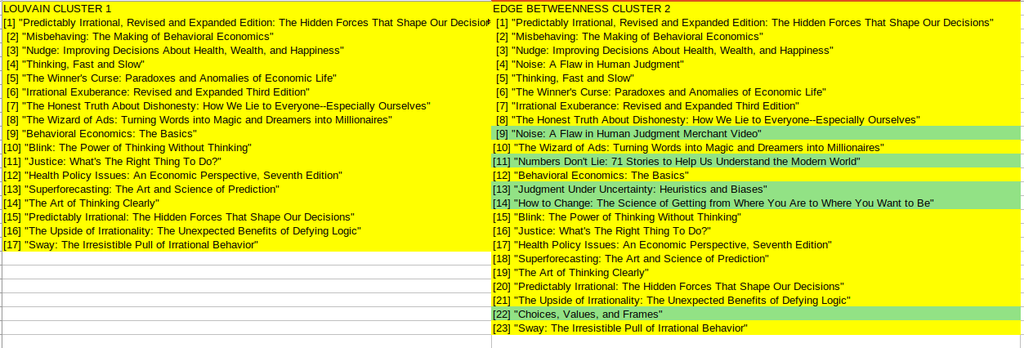

Comparison

## Correlation of Degree Centrality and User’s Ratings

Getting degrrees

```r
data.frame(degree(g)) %>% arrange(desc(`degree.g.`)) -> cdf
cdf$title = rownames(cdf)
rownames(cdf) <- NULL
cdf %>% select(title,`degree.g.`) -> cdf
cdf
```

```
##                                                                                                                                                                                               title
## 1                                                                                                                                    Nudge: Improving Decisions About Health, Wealth, and Happiness
## 2                                                          The Little Book of Common Sense Investing: The Only Way to Guarantee Your Fair Share of Stock Market Returns (Little Books, Big Profits)
## 3                                                                                                                                                                           Thinking, Fast and Slow
## 4                                                                                                                                                                 The Premonition: A Pandemic Story
## 5                                                                                                                                     The Power of Habit: Why We Do What We Do in Life and Business
## 6                                                                                                                                                                   Noise: A Flaw in Human Judgment
## 7                                                                                                                         Atomic Habits: An Easy & Proven Way to Build Good Habits & Break Bad Ones
## 8                                                                                   The Intelligent Investor: The Definitive Book on Value Investing. A Book of Practical Counsel (Revised Edition)
## 9                                            Your Money or Your Life: 9 Steps to Transforming Your Relationship with Money and Achieving Financial Independence: Fully Revised and Updated for 2018
## 10                                                                                                                                                  Misbehaving: The Making of Behavioral Economics
## 11                                                                                       I Will Teach You to Be Rich, Second Edition: No Guilt. No Excuses. No BS. Just a 6-Week Program That Works
## 12                                                                                                 Predictably Irrational, Revised and Expanded Edition: The Hidden Forces That Shape Our Decisions
## 13                                                                                                                A Random Walk Down Wall Street: The Time-Tested Strategy for Successful Investing
## 14                                                                                                         The Simple Path to Wealth: Your road map to financial independence and a rich, free life
```

[output cut: 385 more lines]

## Correlation of Degree Centrality and User’s Ratings

Inner Join Degree and Rating table

```r
df %>% select(title,rating) -> rdf
merge(cdf,rdf,by ="title") -> mdf
unique(mdf) -> umdf
umdf
```

```
##                                                                                                                                                      title
## 1                                                                        A Random Walk Down Wall Street: The Time-Tested Strategy for Successful Investing
## 13                                                                               Atomic Habits: An Easy & Proven Way to Build Good Habits & Break Bad Ones
## 34                                                                           Flow: The Psychology of Optimal Experience (Harper Perennial Modern Classics)
## 45                                              I Will Teach You to Be Rich, Second Edition: No Guilt. No Excuses. No BS. Just a 6-Week Program That Works
## 60                                                                                                Influence: The Psychology of Persuasion, Revised Edition
## 75                                                                                                                                Man's Search for Meaning
## 89                                                                                                         Misbehaving: The Making of Behavioral Economics
## 101                                                                                                                        Noise: A Flaw in Human Judgment
## 116                                                                                         Nudge: Improving Decisions About Health, Wealth, and Happiness
## 117                                                                                         Nudge: Improving Decisions About Health, Wealth, and Happiness
## 143                                                       Predictably Irrational, Revised and Expanded Edition: The Hidden Forces That Shape Our Decisions
## 155                                                                                                                  Sapiens: A Brief History of Humankind
## 170                                                      The Automatic Millionaire, Expanded and Updated: A Powerful One-Step Plan to Live and Finish Rich
## 185                                                                                      The How of Happiness: A New Approach to Getting the Life You Want
```

[output cut: 31 more lines]

## Convert rating to numbers

```r
## get last digit because all over 4
numerify <- function(rating_string){
   return(as.numeric(substr(rating_string,3,3)))
}
umdf %>% mutate(rating_numeric = numerify(rating)) -> xumdf
xumdf %>% filter(!is.na(rating_numeric)) -> yumdf
yumdf
```

```
##                                                                                                                                                     title
## 1                                                                       A Random Walk Down Wall Street: The Time-Tested Strategy for Successful Investing
## 2                                                                               Atomic Habits: An Easy & Proven Way to Build Good Habits & Break Bad Ones
## 3                                                                           Flow: The Psychology of Optimal Experience (Harper Perennial Modern Classics)
## 4                                              I Will Teach You to Be Rich, Second Edition: No Guilt. No Excuses. No BS. Just a 6-Week Program That Works
## 5                                                                                                Influence: The Psychology of Persuasion, Revised Edition
## 6                                                                                                                                Man's Search for Meaning
## 7                                                                                                         Misbehaving: The Making of Behavioral Economics
## 8                                                                                          Nudge: Improving Decisions About Health, Wealth, and Happiness
## 9                                                                                          Nudge: Improving Decisions About Health, Wealth, and Happiness
## 10                                                       Predictably Irrational, Revised and Expanded Edition: The Hidden Forces That Shape Our Decisions
## 11                                                                                                                  Sapiens: A Brief History of Humankind
## 12                                                      The Automatic Millionaire, Expanded and Updated: A Powerful One-Step Plan to Live and Finish Rich
## 13                                                                                      The How of Happiness: A New Approach to Getting the Life You Want
## 14                                        The Intelligent Investor: The Definitive Book on Value Investing. A Book of Practical Counsel (Revised Edition)
```

[output cut: 29 more lines]

## Correlation of Degree Centrality and User’s Ratings

```r
cor(yumdf$rating_numeric,yumdf$degree.g.)
```

```
## [1] -0.5043054
```

## Correlation of Degree Centrality and User’s Ratings

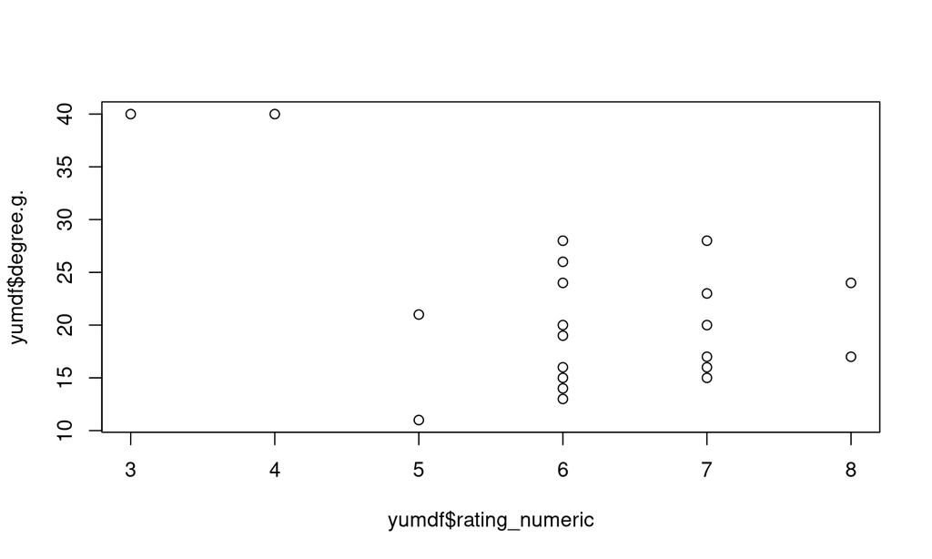

```r
plot(yumdf$rating_numeric,yumdf$degree.g.)
```

## Trying another predictor (betwenness)

```r
data.frame(betweenness(g)) %>% arrange(desc(`betweenness.g.`)) -> cdf
cdf$title = rownames(cdf)
rownames(cdf) <- NULL
cdf %>% select(title,`betweenness.g.`) -> cdf

df %>% select(title,rating) -> rdf
merge(cdf,rdf,by ="title") -> mdf
unique(mdf) -> umdf

## get last digit because all over 4
numerify <- function(rating_string){
   return(as.numeric(substr(rating_string,3,3)))
}
umdf %>% mutate(rating_numeric = numerify(rating)) -> xumdf
xumdf %>% filter(!is.na(rating_numeric)) -> yumdf

cor(yumdf$rating_numeric,yumdf$betweenness.g.)
```

```
## [1] -0.4565538
```

## Trying another predictor

```r
data.frame(degree(g,mode = "out")) -> a
colnames(a) = c("metric")

a %>% arrange(desc(metric)) -> cdf
cdf$title = rownames(cdf)
rownames(cdf) <- NULL
cdf %>% select(title,metric) -> cdf

df %>% select(title,rating) -> rdf
merge(cdf,rdf,by ="title") -> mdf
unique(mdf) -> umdf

## get last digit because all over 4
numerify <- function(rating_string){
   return(as.numeric(substr(rating_string,3,3)))
}
umdf %>% mutate(rating_numeric = numerify(rating)) -> xumdf
xumdf %>% filter(!is.na(rating_numeric)) -> yumdf

cor(yumdf$rating_numeric,yumdf$metric)
```

```
## [1] -0.4238233
```

## Correlation by membership

```r
c3 = cluster_edge_betweenness(gx)
clusterno<- as.data.frame(c3$membership)
title <- as.data.frame(c3$names)
cbind(clusterno,title) -> cludf
colnames(cludf) <- c("clusterno","title")
cludf
```

```
##     clusterno
## 1           1
## 2           2
## 3           2
## 4           2
## 5           3
## 6           1
## 7           4
## 8           5
## 9           1
## 10          2
## 11          4
## 12          6
## 13          7
## 14          2
```

[output cut: 385 more lines]

```r
df %>% select(title,rating) -> rdf
merge(cdf,rdf,by ="title") -> mdf
unique(mdf) -> umdf
umdf %>% mutate(rating_numeric = numerify(rating)) -> xumdf
xumdf %>% filter(!is.na(rating_numeric)) -> yumdf
yumdf
```

```
##                                                                                                                                                     title
## 1                                                                       A Random Walk Down Wall Street: The Time-Tested Strategy for Successful Investing
## 2                                                                               Atomic Habits: An Easy & Proven Way to Build Good Habits & Break Bad Ones
## 3                                                                           Flow: The Psychology of Optimal Experience (Harper Perennial Modern Classics)
## 4                                              I Will Teach You to Be Rich, Second Edition: No Guilt. No Excuses. No BS. Just a 6-Week Program That Works
## 5                                                                                                Influence: The Psychology of Persuasion, Revised Edition
## 6                                                                                                                                Man's Search for Meaning
## 7                                                                                                         Misbehaving: The Making of Behavioral Economics
## 8                                                                                          Nudge: Improving Decisions About Health, Wealth, and Happiness
## 9                                                                                          Nudge: Improving Decisions About Health, Wealth, and Happiness
## 10                                                       Predictably Irrational, Revised and Expanded Edition: The Hidden Forces That Shape Our Decisions
## 11                                                                                                                  Sapiens: A Brief History of Humankind
## 12                                                      The Automatic Millionaire, Expanded and Updated: A Powerful One-Step Plan to Live and Finish Rich
## 13                                                                                      The How of Happiness: A New Approach to Getting the Life You Want
## 14                                        The Intelligent Investor: The Definitive Book on Value Investing. A Book of Practical Counsel (Revised Edition)
```

[output cut: 29 more lines]

```r
#merge
merge(cludf,yumdf) -> cluster_df

cluster_df %>% group_by(clusterno) %>% summarize(mean_rating = mean(rating_numeric))
```

```
## # A tibble: 13 x 2
##    clusterno mean_rating
##        <dbl>       <dbl>
##  1         1        7
##  2         2        5
##  3         3        6
##  4         4        6.67
##  5         5        5
##  6         6        6
##  7         7        6
##  8         8        8
##  9         9        7
## 10        10        6
## 11        11        7
## 12        12        6
## 13        13        6
```

```r
cor(cluster_df$clusterno,cluster_df$rating_numeric)
```

```
## [1] 0.1764989
```